# DWEI5_Aula02_Introducao-ReactJS

Instituto Federal de São Paulo (IFSP)  
[Campus Bragança Paulista/SP](https://bra.ifsp.edu.br)  
**Análise e Desenvolvimento de Sistemas (ADS)**  
**5o. módulo**  
**Profa. Ana Paula Müller Giancoli**  
paulagiancoli@ifsp.edu.br

[figure not shown]

## AULA 02 - INTRODUÇÃO AO REACT JS

### Agenda

- Visão Geral do ReactJS
- Utilizando JSX
- Método Constructor, State, Props, Ciclo de Vida do React
- Configurando o ambiente de desenvolvimento
- Criando nosso primeiro app ReactJS
- Aprofundando no arquivo index.js
- Aprofundando no arquivo App.js (principal contendo nossa aplicação)
- Diversos exemplos utilizando Function Component
- Diversos exemplos utilizando Class Component
- Perguntas

### 1. Visão Geral do React JS ?

- De acordo com [ReactJS](https://pt-br.reactjs.org/tutorial/tutorial.html#what-is-react) é uma biblioteca JavaScript declarativa, eficiente e flexível para criar interfaces com o usuário. Ele permite compor UIs complexas a partir de pequenos e isolados códigos chamados “componentes”.

### 1.1. E o que são componentes?

- Para [GeekHunter](https://blog.geekhunter.com.br/criando-componentes-react-componentes-de-classe-e-funcional-sem-estado/#O_que_sao_componentes_React), são como **funções Javascript**. Aceitam **entradas de dados** conhecidas como **props**, e que retornam **novos elementos React**, conhecidos como **JSX**.
- Por meio dos componentes, podemos dividir as Interfaces de Usuário (UI) em partes independentes e reutilizáveis. Trata cada parte da aplicação como um bloco isolado.
- *Alguns componentes irão controlar o **estado da aplicação** e fazer **chamadas em uma API externa** para popular dados enquanto outros irão se preocupar apenas com a **renderização desses dados** para o usuário*.

### 1.2. E como são classificados estes componentes?

- Conforme [GeekHunter](https://blog.geekhunter.com.br/criando-componentes-react-componentes-de-classe-e-funcional-sem-estado/#O_que_sao_componentes_React) são classificados em:
- **Componentes de Classe (Class Component)**: são componentes capazes de gerenciar o próprio estado, herdam os chamados métodos de ciclo de vida do React. Os eventos são manipuláveis por meio dos métodos que podem ser chamados dentro do componente ou em seus filhos.
  - No **componente de classe** precisamos estender a classe **Component** padrão do React e acessar seus valores através do **objeto this**.
- **Componentes Funcionais (Function Component) sem estados**: são representados por funções JavaScript e como o nome sugere, não se preocupam (e nem devem se preocupar) com o gerenciamento de estado do componente, mas apenas com a apresentação dos dados na aplicação.
  - No **componente funcional**, o **this não existe**, pois o mesmo é apenas uma função que pode acessar os valores do objeto diretamente, exatamente como se estivesse recebendo esses dados por parâmetros.
- **Exemplo**: quando temos somente uma linha.

```python
*************
/* Exemplo */
*************

const Bemvindo = () => <h2>Bem-vindo(a)</h2>
```

- **Exemplo**: quando temos diversas linhas é necessário as chaves, o return e uma div.
- Caso não utilize a **div**, será exibido um erro.
- Dentro das chaves é possível escrever o código javascript no html.

```python
*************
/* Exemplo */
*************

function App() {
  return (
    <div className="App">

      // Adicionar este bloco
      <div>
        <Bemvindo />
      </div>

      <header className="App-header">
      ...
```

[figure not shown]

```python
*************
/* Exemplo */
*************

const Bemvindo = () => <h2>Bem-vindo(a)</h2>

// Adicionar este bloco
const Olamundo = () => {
  return(
    <div>
      <h2>Olá Mundo!</h2>
    </div>
  )
}


function App() {
  return (
    <div className="App">
      <div>
        <Bemvindo />
        <Olamundo />
      </div>
      <header className="App-header">
      ...
```

[figure not shown]

- **Exemplo**: Utilizando **props**.
- Componentes: Bemvindo, Olamundo, App.

```python
****************************
/* Exemplo arquivo App.js */
****************************

import React from 'react';

const Bemvindo = () => <h2>Bem-vindo(a)</h2>

// Adicionar este bloco
const Olamundo = (props) => {
  return(
    <div>
      <h2>Olá Mundo! { props.nome }</h2>
      <h3>Tenho { props.idade } anos.</h3>
    </div>
  )
}


function App() {
  return (
    <div className="App">
      <Bemvindo />

      // Adicionar este bloco
      <Olamundo nome="Ana Giancoli" idade = "10"/>

    </div>
  );
}

export default App;
```

[figure not shown]

### 1.2.1. E qual usar?

- A receita de bolo sugerida por [GeekHunter] é **escolha *componentes funcionais* sempre que possível (por serem mais simples e mais rápidos), ou seja, quando você apenas quer exibir alguma UI**.
- E use **componentes de classe** sempre que existir tarefas mais complexas a serem feitas, como lidar com alguma lógica, gerenciar o estado e manipular eventos.
- **Veja os exemplos propostos por eles**:

| Cenário Real | Escolhas para cada cenário Real |
| --- | --- |
| Você quer criar um componente que exibe o avatar do usuário | Componente funcional sem estado |
| Você quer criar um componente padrão para exibir posts | Componente funcional sem estado |
| Você quer criar um componente de dropdown | Componente de classe |
| Você quer criar um componente de busca | Componente de classe |
| Você quer criar uma tabela para exibir uma lista de dados | Componente funcional sem estado |
| Você quer criar um componente que valide os dados de um formulário | Componente de classe |
| Você quer criar um componente que exiba um loader | Componente funcional sem estado |

### 1.2.2. Exemplos

##### **Exemplo de Função Javascript**

```python
*******************************
/* Exemplo Função Javascript */
*******************************


let mult = function(a) {
    return 2 * a;
}
console.log(mult(2))  // 4
```

##### **Exemplo de Arrow Functions Javascript**

```python
****************************************
/* Exemplo Arrow Functions Javascript */
****************************************


mult = (a) => {
    return 2 * a;
 }
console.log(mult(5));
```

##### **Exemplo de um componente App**

- A maneira mais simples de definir um componente é escrever uma função JavaScript:

```python
***************
/* Exemplo 1 */
***************

import logo from './logo.svg';
import './App.css';
import React from 'react';

const Bemvindo = () => <h2>Bem-vindo(a)</h2>
const Olamundo = (props) => {
  return(
    <div>
      <h2>Olá Mundo! { props.nome }</h2>
      <h3>Tenho { props.idade } anos.</h3>
    </div>
  )
}


// Adicionar este bloco
function Welcome(props) {
  return <h1>Hello, { props.nome }</h1>;
}



function App() {
  return (
    <div className="App">
      <div>
        <Bemvindo />

      // Adicionar este bloco
        <Welcome nome="Paula"/>


        <Olamundo nome="Ana Giancoli" idade = "10"/>
      </div>
      <header className="App-header">
      ...
      /header>

      // Adicionar este bloco
      <div>
        <ExibirPosts />
      </div>

    </div>

  );
}

export default App;
```

- **export default App**: Deixa o App disponível para ser utilizado fora da classe.

[figure not shown]

##### **Exemplo de Componente Funcional**

```python
**********************************************
/* Exemplo Componente Funcional ExibirPosts */
**********************************************

import React from 'react';

const ExibirPosts = () => {
    return(
        <div>
            <h1>Título Post </h1>
            <p>Descrição do Post</p>
        </div>
    )}
```

```python
****************************
/* Exemplo Arquivo App.js */
****************************

import logo from './logo.svg';
import './App.css';
import React from 'react';

const Bemvindo = () => <h2>Bem-vindo(a)</h2>
const Olamundo = (props) => {
  return(
    <div>
      <h2>Olá Mundo! { props.nome }</h2>
      <h3>Tenho { props.idade } anos.</h3>
    </div>
  )
}

function Welcome(props) {
  return <h1>Hello, { props.nome }</h1>;
}


// Adicionar este bloco
const ExibirPosts = () => {
    return(
        <div>
            <h1>Título Post </h1>
            <p>Descrição do Post</p>
        </div>
    )
}


function App() {
  return (
    <div className="App">
      <div>
        <Bemvindo />
        <Welcome nome="Paula"/>
        <Olamundo nome="Ana Giancoli" idade = "10"/>
      </div>
      <header className="App-header">
      ...
      </header>

      // Adicionar este bloco
      <div>
        <ExibirPosts />
      </div>

    </div>

  );
}

export default App;
```

[figure not shown]

##### **Exemplo de Componente de Classe**

```python
***********************************************
/* Exemplo Componente de Classe ExibirPosts */
***********************************************

import React, { Component } from 'react';

class ExibirPosts extends Component {
    render() {
        return(
            <div>
                <h1> Título Post </h1>
                <p>Descrição do Post</p>
            </div>
        )
    }
}
```

```python
****************************
/* Exemplo Arquivo App.js */
****************************


import logo from './logo.svg';
import './App.css';

// Adicionar este bloco
import React, { Component } from 'react';

const Bemvindo = () => <h2>Bem-vindo(a)</h2>
const Olamundo = (props) => {
  return(
    <div>
      <h2>Olá Mundo! { props.nome }</h2>
      <h3>Tenho { props.idade } anos.</h3>
    </div>
  )
}

function Welcome(props) {
  return <h1>Hello, { props.nome }</h1>;
}


// Modificar este bloco
class ExibirPosts extends Component {
  render() {
    return(
        <div>
            <h1>Título Post class</h1>
            <p>Descrição do Post class</p>
        </div>
    )
  }
}


function App() {
  return (
    <div className="App">
      <div>
        <Bemvindo />
        <Welcome nome="Paula"/>
        <Olamundo nome="Ana Giancoli" idade = "10"/>
      </div>
      <header className="App-header">
      ...
      </header>
      <div>
        <ExibirPosts />
      </div>
    </div>

  );
}

export default App;
```

[figure not shown]

### 2. Utilizando JSX

- **JSX** é abreviação de JavaScript XML. O React usa o JSX para facilitar a leitura e gravação do código HTML, além de melhorar o desempenho do site ou app.
- O JSX foi introduzido pelo React.

```python
************************
/* Exemplo usando JSX */
************************

const HelloWorld = <h1> Hello World! </h1>
```

### 2.1. Convenção React

- [React](https://pt-br.reactjs.org/docs/jsx-in-depth.html#user-defined-components-must-be-capitalized): Componentes definidos pelo Usuário precisam começar com letras maiúsculas. Acesse o link indicado no React.
- **Observação**: Sempre inicie os nomes dos componentes com uma letra maiúscula. Pois, o **React trata componentes começando com letras *minúsculas* como tags do DOM**.
- Por exemplo, **< div /> representa uma tag div do HTML**, mas **< Welcome /> representa um componente** e requer que **Welcome esteja no escopo**.

### 3. Método Constructor, State, Props

### 3.1. Método Constructor

- O **método constructor** é um tipo especial de método para criar e iniciar um objeto criado pela classe.
- Só pode existir um método especial com o nome **"constructor"** dentro da classe. Um erro de sintaxe -- **SyntaxError** -- será lançado se a classe possuir mais do que uma ocorrência do método constructor.
- *Um constructor pode usar a palavra-chave **super** para chamar o constructor de uma classe pai*.
- É um dos métodos principais do **ciclo de vida do React**, mas não é necessariamente obrigatória a sua implementação.
- É utilizado quando é preciso inicializar o state de um componente.
- O **método constructor** de um componente React é chamado antes do componente ser montado.

### 3.2. Props

- As **props** -- abreviação de "properties".

### 3.2.1. **E o que são props?**

- **Props** é a forma de como as propriedades são passadas para os componentes, começando pelo componente principal.
- E todo o componente filho vai receber as propriedades do parente.
- Em um **componente funcional (Function Component)**, as **props** devem ser passadas, usando a **palavra reservada props** como o argumento da função.

```python
***********************************************
/* Exemplo Componente Funcional usando props */
***********************************************

import React from 'react';

const ExibirPosts = props => {
    return(
        <div>
            <h1>Título Post: { props.titulo } </h1>
            <p>Descrição do Post: { props.descricao }</p>
        </div>
    )
}
```

```python
****************************
/* Exemplo Arquivo App.js */
****************************

import logo from './logo.svg';
import './App.css';
import React, { Component } from 'react';

const Bemvindo = () => <h2>Bem-vindo(a)</h2>
const Olamundo = (props) => {
  return(
    <div>
      <h2>Olá Mundo! { props.nome }</h2>
      <h3>Tenho { props.idade } anos.</h3>
    </div>
  )
}

function Welcome(props) {
  return <h1>Hello, { props.nome }</h1>;
}


// Modificar este bloco
const ExibirPosts = props => {
  return(
      <div>
        <h1>Título Post class: { props.titulo }</h1>
        <p>Descrição do Post class: { props.descricao }</p>
      </div>
    )
}


function App() {
  return (
    <div className="App">
      <div>
        <Bemvindo />
        <Welcome nome="Paula"/>
        <Olamundo nome="Ana Giancoli" idade = "10"/>
      </div>
      <header className="App-header">
      ...
      </header>

      // Adicionar este bloco
      <div>
        <ExibirPosts titulo="Primeiro Post" descricao="descrição de um post publicado!"/>
      </div>

    </div>

  );
}

export default App;
```

[figure not shown]

- Em um **componente de classe (Class Component)**, as **props** já são passadas por padrão (default). E para acessar as props, utiliza-se **this.props.atributo**. No exemplo os atributos são, título e descrição.

```python
***********************************************
/* Exemplo Componente de classe usando props */
***********************************************

import React, { Component } from 'react';

class ExibirPosts extends Component {
    render() {
        return(
            <div>
                <h1>Título Post: { this.props.titulo } </h1>
                <p>Descrição do Post: { this.props.descricao }</p>
            </div>
        )
    }
}
```

```python
****************************
/* Exemplo Arquivo App.js */
****************************

import logo from './logo.svg';
import './App.css';
import React, { Component } from 'react';

const Bemvindo = () => <h2>Bem-vindo(a)</h2>
const Olamundo = (props) => {
  return(
    <div>
      <h2>Olá Mundo! { props.nome }</h2>
      <h3>Tenho { props.idade } anos.</h3>
    </div>
  )
}

function Welcome(props) {
  return <h1>Hello, { props.nome }</h1>;
}

// Modificar este bloco
class ExibirPosts extends Component {
  render() {
      return(
          <div>
              <h1>Título Post: { this.props.titulo } </h1>
              <p>Descrição do Post: { this.props.descricao }</p>
          </div>
      )
  }
}



function App() {
  return (
    <div className="App">
      <div>
        <Bemvindo />
        <Welcome nome="Paula"/>
        <Olamundo nome="Ana Giancoli" idade = "10"/>
      </div>
      <header className="App-header">
      ...
      </header>

      // Modificar este bloco
      <div>
        <ExibirPosts titulo="Post com this.props" descricao="descrição de um post publicado!"/>
      </div>

    </div>

  );
}

export default App;
```

[figure not shown]

### 3.3. State

- O **state**, em React, é onde guardamos os dados do nosso componente.

### 3.4. Qual a diferença entre State e Props ?

- **Props** e **state** são objetos JavaScript.
- Apesar de ambos guardarem informações que influenciam no resultado da renderização, eles são diferentes por uma razão importante:
  - as **props** são passados para o componente como parâmetros de funções.
  - e o **state** é gerenciado de dentro do componente como variáveis declaradas dentro de uma função.

### E o que faz o setState?

- **setState( )** agenda uma atualização para o objeto state de um componente. Quando o state muda, o componente responde renderizando novamente.
- Não se deve utilizar o **setState( )** no **método constructor**, devemos atribuir o estado inicial diretamente em **this.state**.

### **Exemplo**:

- Criado um componente para Exibir Posts utilizando o **conceito de componentes de classe**. Onde o post terá um **estado (state)** de selecionado ou não (clicked).
- Entendendo o código:
  - **constructor(props)** : criando o constructor da classe que recebe props.
  - **super(props)** : definindo o método super(props) que indica ao React para utilizar o método constructor da classe pai.
  - **this.state = { clicked: false }** : Definindo o state inicial como false.
  - **< p>Selecionado: { this.state.clicked } < /p>**: acessando o **state clicked** do componente. Será false.
  - Ao utilizarmos o **setState**, estamos informando ao React que o estado do componente mudou, o que vai gerar uma série de eventos e atualizações posteriores. this.setState({ clicked: true });

```python
*****************************
/* Parte do Arquivo App.js */
*****************************

...

class ExibirPosts extends Component {
  constructor(props) {
    super(props)
    this.state = { clicked: false}
  }

  render() {
      return(
          <div>
              <h1>Título: { this.props.titulo } </h1>
              <p>Descrição: { this.props.descricao } </p>
              <p>Selecionado: { this.state.clicked } </p>
              { console.log(this.state.clicked) }
          </div>
      )
  }
}

function App() {
  return (
    <div className="App">
      <div>
        <Bemvindo />
        <Welcome nome="Paula"/>
        <Olamundo nome="Ana Giancoli" idade = "10"/>
      </div>
      <header className="App-header">
        ...
      </header>
      <div>
        <ExibirPosts titulo="Utilizando Constructor" descricao="com this.props e this.state"/>
      </div>
    </div>

  );
}

export default App;
```

```python
****************************
/* Exemplo Arquivo App.js */
****************************

import logo from './logo.svg';
import './App.css';
import React, { Component } from 'react';

const Bemvindo = () => <h2>Bem-vindo(a)</h2>
const Olamundo = (props) => {
  return(
    <div>
      <h2>Olá Mundo! { props.nome }</h2>
      <h3>Tenho { props.idade } anos.</h3>
    </div>
  )
}

function Welcome(props) {
  return <h1>Hello, { props.nome }</h1>;
}


// Modificar este bloco
class ExibirPosts extends Component {
  constructor(props) {
    super(props)
    this.state = { clicked: false}
  }

  render() {
      return(
          <div>
              <h1>Título: { this.props.titulo } </h1>
              <p>Descrição: { this.props.descricao } </p>
              <p>Selecionado: { this.state.clicked } </p>
              { console.log(this.state.clicked) }
          </div>
      )
  }
}


function App() {
  return (
    <div className="App">
      <div>
        <Bemvindo />
        <Welcome nome="Paula"/>
        <Olamundo nome="Ana Giancoli" idade = "10"/>
      </div>
      <header className="App-header">
        ...
      </header>

      // Modificar este bloco
      <div>
        <ExibirPosts titulo="Utilizando Constructor" descricao="com this.props e this.state"/>
      </div>

    </div>

  );
}

export default App;
```

[figure not shown]

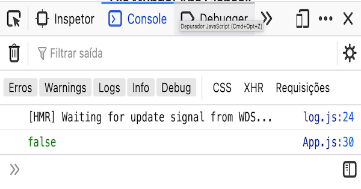

### 4. Configurando o ambiente de desenvolvimento

### 4.1. Instalando NodeJS

- Segue um tutorial para instalar o [NodeJS, NPM, React no Windows](https://www.devmedia.com.br/como-instalar-o-node-js-npm-e-o-react-no-windows/40329).
- Acessar o site do [NodeJS](https://nodejs.org/en/), baixar a **versão LTS** (Long-term support), que significa suporte de longo prazo.
- Juntamente com o **NodeJS** é instalado o **NPM**, conhecido como, **Gerenciador de Pacotes do Node** (Node Package Manager) e que é muito útil no desenvolvimento, pois por meio dele é possível instalar os pacotes e suas dependências que serão utilizados em nossa aplicações.
- Existe um outro gerenciador de pacotes e dependências para Javascript, é o [**YARN**](https://yarnpkg.com/).
- Em nossas aulas utilizaremos o **NPM**.

### 4.2. Instalando o VSCode

- Acessar o site do [VSCode](https://code.visualstudio.com/) e efetuar o download.

### 4.2.1. Instalando extensões para o VScode:

- Não é obrigatório, mas auxilia na codificação.
  - React-Native/React/Redux snippets for es6/es7
  - Reactjs code snippets
  - vscode-icons

### 4.3. Instalando o React

- Para instalar o React globalmente na máquina, utilize o **NPM**, abra seu terminal e digite:

```python
npm install -g create-react-app
```

- Para quem instalou globalmente, utilizando o **NPM**, acesse a pasta onde deseja criar seu projeto e digite:

```python
create-react-app meusite
```

### 4.4. O que é NPX?

- De acordo com [Julio Henrique - stackoverflow](https://pt.stackoverflow.com/questions/433378/qual-a-diferen%C3%A7a-entre-npm-e-npx):
  - **NPM** é o gerenciador de pacotes node, ele irá instalar na sua máquina um pacote para que você possa utilizalo em outros projetos sem precisar baixar novamente.
  - **NPX** ele irá usar o pacote sem precisar baixar em sua máquina, sendo assim voce irá instalar um pacote no seu projeto ou até mesmo usar esse pacote, sem baixar os arquivos em sua máquina.
  - Para que o **NPX é util**?
    - Já instalou algum pacote global e precisou usá-lo pouquíssimas vezes?
    - Já teve problemas de incompatibilidade com pacotes globais por diferença de versões em múltiplos projetos?
    - Já sentiu que sua máquina está poluída por diversos pacotes globais?
- Quando você instala react-native em sua máquina e começa um projeto usando ele ao invés de NPX, você está usando a versão do react-native do pacote instalado em seu node_modules, já quando usa npx você usa um pacote na nuvem do node, então isso te dá liberdade para usar até outras versões que não tem em sua máquina.

### 5. Criando nosso primeiro app ReactJS

- De acordo com [ReactJS](https://pt-br.reactjs.org/docs/create-a-new-react-app.html), recomenda-se algumas soluções como:
  - Se você está aprendendo React ou criando um novo **single-page app**, use [**Create React App**](https://pt-br.reactjs.org/docs/create-a-new-react-app.html#create-react-app).
  - Se você está fazendo um **site renderizado no servidor (SSR)** com Node.js, tente [**Next.js**](https://pt-br.reactjs.org/docs/create-a-new-react-app.html#nextjs). *Observação*: [Guia Oficial NextJS](https://nextjs.org/learn/basics/create-nextjs-app).
  - Se você está fazendo um **site estático orientado a conteúdo**, experimente [**Gatsby**](https://pt-br.reactjs.org/docs/create-a-new-react-app.html#gatsby). *Observação*: [Guia Oficial Gatsby](https://www.gatsbyjs.com/docs/).
  - Se você está montando uma **biblioteca de componentes ou integrando com um código-base existente**, veja Toolchains [**Mais Flexíveis**](https://pt-br.reactjs.org/docs/create-a-new-react-app.html#more-flexible-toolchains).
- Em resumo, **NPX** é um **package runner** do NPM. Ele executa as bibliotecas que podem ser baixadas do **site npmjs**.
- Essas bibliotecas ficam em um banco de dados chamado **NPM Registry**, que também podem ser baixadas via **CLI** com **npm** ou **yarn** e com **npx**.
- Para instalar o **React** utilizando o **NPX**, abra seu terminal na pasta que deseja criar seus projetos e digite:

```python
npx create-react-app my-app
```

- Onde **my-app** é o nome da pasta da sua aplicação que será criada.
- Para iniciarmos então, vamos criar uma aplicação chamada de **meusite**. Logo, abra o terminal, e digite a instrução será:

```python
npx create-react-app meusite
```

- **Observação**: vai demorar um pouquinho, depende da sua conexão com a internet.

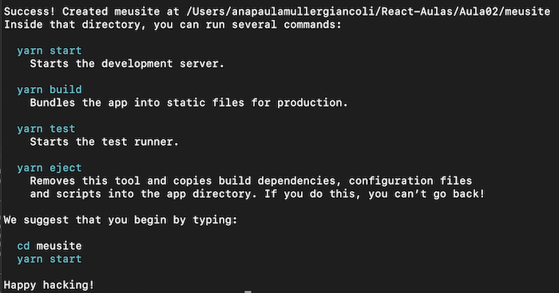

### 5.1. Entendendo a estrutura de pasta criadas pelo React para o meu projeto -- **meusite**

- São criadas as seguintes pasta e arquivos:
  - node_modules
  - public
  - src
  - .gitignore
  - package.json
  - Readme.md
  - yarn.lock
- Ao acessar a pasta do seu projeto -- **meusite**, você verá esta estrutura de pastas dentro da pasta **meusite**:

[figure not shown]

- O que significa cada uma das pastas e arquivos:
  - **node_modules**: é a biblioteca do NodeJS contendo todas as dependências necessárias para nosso projeto.
  - **public**: esta pasta contém todos os arquivos que estarão disponíveis para o usuário final.
  - **src**: onde ficarão todos os códigos e imagens. O componente principal é o App.js.
  - **.gitignore**: é um arquivo que é criado na raiz do nosso projeto para poder ignorar arquivos e pastas do versionamento. Dentro dele colocamos todos os arquivos e pastas que serão ignorados pelo git em um commit.
  - **package.json**: é uma espécie de manifesto do seu projeto. Ele pode fazer várias coisas, completamente não relacionadas. Ele é um repositório central de configurações de ferramentas, por exemplo. No nosso projeto, ele conterá as indicações de todas as dependências.
  - **Readme.md**: contém informações necessárias para entender o objetivo do projeto.
  - **yarn.lock**: esses arquivos de bloqueio bloqueiam as dependências instaladas em uma versão específica e garantem que cada instalação resulte exatamente na mesma estrutura de arquivos em node_modules em todas as máquinas.

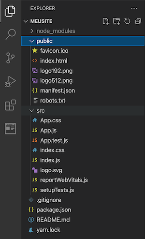

- Explorando um pouco mais:
  - **public**:
    - **favicon.ico**: é o ícone da barra de endereços / Título.
    - **index.html**: que carregará a página principal, esta não será modificada. Pois, nossa aplicação será carregada nesta div por meio deste id **root**: < div id="root">< /div>
    - **logo192.png, logo512.png**: são os logos do React. Excluiremos posteriormente.
    - **manifest.json**: neste momento não utilizaremos, mas ele serve de configuração para as aplicações **PWA (Progressive Web Pages**). De uma forma simplificada, é uma aplicação web que está disponível em um servidor e é acessado pelo usuário via smartphone. A aplicação web é apresentada ao usuário como se fosse uma aplicação nativa. Existem muitas funcionalidades para serem utilizadas. Se quiser aprender mais sobre PWA, consulte [Web.dev](https://web.dev/progressive-web-apps/?gclid=Cj0KCQjwxJqHBhC4ARIsAChq4asFK8ZGZwDNoDg8nGEwPgxgXq0SlLobM8ToCkYY1A_VHRKHh9rvXeAaAuEvEALw_wcB).
    - **robots.txt**: é um arquivo de texto com instruções para rastreadores de mecanismos de pesquisa (SEO). É armazenado no diretório raiz de um domínio. Portanto, é o primeiro documento que os rastreadores abrem ao visitar seu site. No entanto, o arquivo não controla apenas o rastreamento. Você também pode integrar um link ao mapa do site, o que dá aos rastreadores de mecanismos de pesquisa uma visão geral de todos os URLs existentes em seu domínio. Para saber mais, acesse Seobility.net.
  - **src**:
    - **App.css**: é o arquivo de estilos do App.js.
    - **App.js**: é o arquivo proncipal de nossa aplicação.
    - **App.test.js**: é um arquivo utilizado para testes unitários.
    - **index.css**: é o arquivo de estilos do index.js.
    - **index.js**: é responsável por renderizar o nosso App dentro da página index.html do public. *Lembra ? Dentro da div com id igual a root*.
    - **logo.svg**: é o logo do React em svg.
    - **reportWebVitals.js**: O React permite medir o desempenho e a capacidade de resposta de seu aplicativo. Isso é feito monitorando as métricas definidas pelo web vitals e medidas usando a biblioteca web-vitals. Para aprofundar, consulte [Create React App](https://create-react-app.dev/docs/measuring-performance/).
    - **setupTestes.js**: é um arquivo de configuração de testes. Leia o artigo [Testes Automatizados em React por hiago Ferreira](https://medium.com/luizalabs/testes-automatizados-em-react-e431db826d65).

### 5.2. Iniciando a aplicação

- Para startar a aplicação, é necessário subir o servidor, para isso, abra o terminal, tem que estar no mesmo nível do package.json, logo, acessamos a pasta do projeto, no nosso caso em -- **meusite**, e digitamos a instrução:

```python
npm start
```

- **Ou ainda**:

```python
yarn start
```

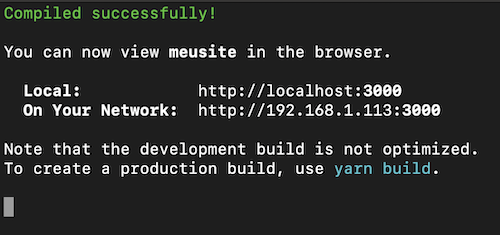

[figure not shown]

- Observação:
  - Para não ficar subindo e descendo o servidor a cada alteração, usar o nodemon.
  - Para instalar: utilize a instrução: onde -g é para instalar globalmente.

```python
npm install -g nodemon
```

- Pode ser instalado localmente, com uma dependência de desenvolvimento:
  - Com uma instalação local, o nodemon não estará disponível no caminho do seu sistema. Em vez disso, a instalação local do nodemon pode ser executada chamando-o de um script npm (como npm start) ou usando npx nodemon. Consulte [Nodemon](https://www.npmjs.com/package/nodemon).

```python
npm install --save-dev nodemon
```

### 6. Aprofundando no arquivo index.js

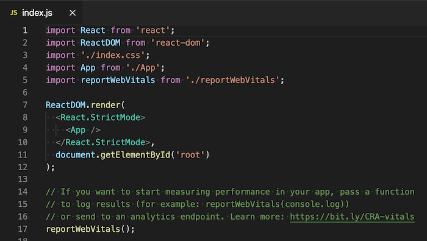

### 6.1. O que significa cada linha ?

- **import React from 'react'**: é necessário este import para utilizarmos a sintaxe [JSX](https://pt-br.reactjs.org/docs/introducing-jsx.html). É recomendável usar JSX com o React para descrever como a UI deveria parecer, no caso, nossa aplicação **< App />**.
- **import ReactDOM from 'react-dom'**: é como se fosse uma ligação (cola) entre os componentes e o DOM. Ele será responsável por meio do método render( ) renderizar os componentes do nosso App no DOM.
- **import '/.index.css'**: é responsável por carregar os estilos a serem utilizados no index.js.
- **import App from './App'**: é utilizado para carregar o nosso App que será utilizado dentro do ReactDOM para ser renderizado.
- **import reportWebVitals from './reportWebVitals'**: é responsável por importar o arquivo reportWebVitals para medir o desempenho e a capacidade de resposta de seu aplicativo.
- **ReactDOM.render( )**: É responsável por renderizar nosso App na página index.html disponível em public, por meio da div com id igual a root.
- **React.StrictMode**: é responsável por melhorar a qualidade do código. Ou seja, o código será executado de forma mais rigorosa. Ativando o strict mode somos obrigados a ser mais regrados na escrita de nossos códigos. Utilizarmos as regras etc. Para saber mais, consulte [MDN Docs](https://developer.mozilla.org/pt-BR/docs/Web/JavaScript/Reference/Strict_mode).
- **< App />**: é a nossa aplicação que foi importada na linha 4. Ela foi definida no arquivo App.js apresentado abaixo.
- **document.getElementById('root')**: elemento que receberá nossa aplicação. Está localizado no arquivo index.html da pasta public.

### 7. Aprofundando no arquivo App.js (principal contendo nossa aplicação)

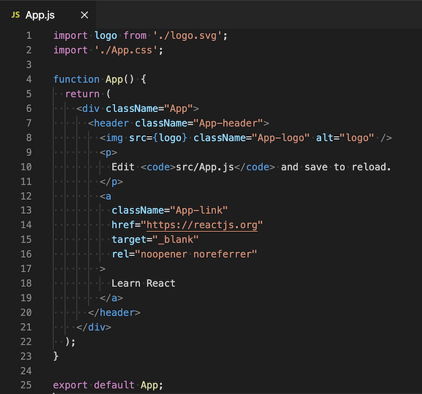

- Tudo o que estiver definido dentro do **return( )**, faz parte da sua linguagem de marcação (html) e será sempre apresentado à tela quando rendereizado a aplicação.

### 8. Diversos exemplos utilizando Function Component

- **Importante**: podemos criar nossos próprios componentes. Lembrando que para isso, devem ser criados com a primeira letra maiúscula.

### 8.1. **Exemplo**: escrevendo de forma diferente o que foi mencionado no início desta aula.

- Acrescentando um componente chamado Sobrenome e que recebe props como parâmetro de função.

```python
***************************************************
/* Exemplo Arquivo App.js - Componente Funcional */
***************************************************

import React from 'react';

const Bemvindo = () => <h2>Bem-vindo(a)</h2>
const Olamundo = (props) => {
  return(
    <div>
      <h2>Olá Mundo! { props.nome }</h2>
      <h3>Tenho {  props.idade } anos.</h3>
    </div>
  )
}

function Sobrenome(props) {
  return (
    <p>Sobrenome: { props.sobrenome }</p>);
}


function App() {
  return (
    <div className="App">
      <Bemvindo />
      <Olamundo nome="Ana Giancoli" idade="23"/>
      <Sobrenome sobrenome="Müller" />
    </div>
  );
}

export default App;
```

### 8.2. **Exemplo**: passando de um componente funcional para outro.

- Componentes: Equipe, Sobre.

```python
***************************************************
/* Exemplo Arquivo App.js - Componente Funcional */
***************************************************

import React from 'react';

const Equipe = (props) => {
  return(
    <div>
      <Sobre nome = { props.nome } cargoF = { props.cargo } idadeF = { props.idade } />
    </div>
  )
}

const Sobre = (props) => {
  return(
    <div>
      <h2> Olá sou(a) { props.nome } ! </h2>
      <h3> Sou { props.cargoF }. </h3>
      <h3> Eu tenho { props.idadeF } </h3>
    </div>
  )
}

function App() {
  return (
    <div className="App">
      <Equipe nome="Ana Giancoli" idade="23" cargo="Analista" />
    </div>
  );
}

export default App;
```

### 8.3. **Exemplo**: separando as responsabilidades de cada componente funcional.

```python
***************************************************
/* Exemplo Arquivo App.js - Componente Funcional */
***************************************************

import React from 'react';

// Separando as responsabilidades de cada componente
const Equipe = (props) => {
  return(
    <div>
      <Sobre nome = { props.nome } cargoF = { props.cargo } idadeF = { props.idade } />
      <Social go={ props.google }/>
      <hr/>
    </div>
  )
}

// Separando as responsabilidades de cada componente
const Sobre = (props) => {
  return(
    <div>
      <h2> Olá sou(a) { props.nome } ! </h2>
      <h3> Sou { props.cargoF }. </h3>
      <h3> Eu tenho { props.idadeF } </h3>
    </div>
  )
}

// Separando as responsabilidades de cada componente
const Social = (props) => {
  return(
    <div>
      <a> Facebook</a>
      <a href={ props.go }> Google</a>
      <a> Linkedin</a>
    </div>
  )
}

function App() {
  return (
    <div className="App">
      <Equipe nome="Ana Giancoli" idade="23" cargo="Analista" google="http://google.com"/>
      <Equipe nome="Paula Müller" idade="29" cargo="Analista Senior" />
    </div>
  );
}

export default App;
```

### 9. Diversos exemplos utilizando Class Component

### 9.1. **Exemplo**:

- Utilizamos o **this** dentro da classe, indicando que estamos usando os componentes dela.

```python
*****************************************
/* Exemplo Componente de Classe Equipe */
*****************************************

import React, { Component } from 'react';

class Equipe extends Component {
  render(){
    return(
      <div>
        <Sobre nome = { this.props.nome } cargoF = { this.props.cargo } idadeF = { this.props.idade } />
        <Social google={ this.props.google }/>
        <hr/>
      </div>
    );
  }
}
```

### 9.2. **Exemplo**: separando as responsabilidades.

- Utizando **Function Component** (Social) e **Class Component** (Equipe, Sobre).

```python
***************************************************************
/* Exemplo Arquivo App.js - Componente de Classe | Funcional */
***************************************************************

import React, { Component } from 'react';

class Equipe extends Component {
  render(){
    return(
      <div>
        <Sobre nome = { this.props.nome } cargoF = { this.props.cargo } idadeF = { this.props.idade } />
        <Social go={ this.props.google }/>
        <hr/>
      </div>
    );
  }
}

class Sobre extends Component {
  render(){
    return(
      <div>
        <h2> Olá sou(a) { this.props.nome } ! </h2>
        <h3> Sou { this.props.cargoF }. </h3>
        <h3> Eu tenho { this.props.idadeF } </h3>
      </div>
    );
  }
}


const Social = (props) => {
  return(
    <div>
      <a> Facebook</a>
      <a href={ props.go }> Google</a>
      <a> Linkedin</a>
    </div>
  )
}

function App() {
  return (
    <div className="App">
      <Equipe nome="Ana Giancoli" idade="23" cargo="Analista" google="http://google.com"/>
      <Equipe nome="Paula Müller" idade="29" cargo="Analista Senior" />
    </div>
  );
}

export default App;
```

### 9.3. Dentro de um class component, é possível termos [estados](https://pt-br.reactjs.org/docs/state-and-lifecycle.html).

- O **state** do componente é similar as **props**, mas é privado e totalmente controlado pelo componente.
- Quando precisamos atualizar a UI algumas vezes, é importante que utilizemos o **state** que nos permite modificar a UI a cada atualização da variável.
- Você precisa ter cuidado com o significado do this nos callbacks do JSX. Em JavaScript, os **métodos de classe não são vinculados por padrão**.
- Se você esquecer de fazer o **bind** de **this.aumentar** ou **this.diminuir** e passá-lo para um **onClick**, o this será **undefined** quando a função for realmente chamada.
- Este não é um comportamento específico do React.
- É uma parte de como funcionam as funções em JavaScript.

### 9.3.1. Manipulação de Eventos

- De acordo com [React](https://pt-br.reactjs.org/docs/handling-events.html), manipular eventos no React é bem semelhante à manipulação do DOM em HTML, com algumas particularidades em sua sintaxe.
- **No HTML**:

```python
<button onClick="marcar()">
  Marcar opção
</button>
```

- **No React**:

```python
<button onClick= { marcar }>
  Marcar opção
</button>
```

- Geralmente, se você referir a um método **sem parênteses** ( ) depois dele, como **onClick={ this.aumentar }**, você deve fazer o **bind manual** deste método.
- Ao utilizarmos a chamada do método passando os parênteses com ou sem parâmetros, estamos chamando este método toda vez que o componente é renderizado. É como se já estivesse sendo executado:

```python
<button onClick= { this.diminuir( ) }> </button>
```

- Logo, para que isso não ocorra, precisamos chamar o método por meio de uma função anônima, que será executado somente quando pressionado:

```python
<button onClick= { ( ) => this.diminuir( ) } > </button>
```

- **Exemplos**:

```python
***************************************************
/* Exemplo Arquivo App.js - Componente de Classe */
***************************************************

import './App.css';
import React, { Component } from 'react';

class App extends Component {

  constructor(props){
    // acessar todas as informações do componente dentro do render()
    super(props);
    // todas as states relacionadas ao App (componente)
    this.state = {
      nome: 'Ana Giancoli',
      contador: 0
    };
    // para acessar a função setState é necessário utilizar o método bind com passagem do this.
    this.aumentar = this.aumentar.bind(this);
    this.diminuir = this.diminuir.bind(this);
  }

  aumentar() {
    console.log("Aumentado!")
    let state = this.state;
    state.contador += 1;
    state.nome = "Ana Paula Müller Giancoli";
    this.setState(state);
  }

  diminuir() {
    console.log("Diminuido!")
    let state = this.state;

    if (state.contador === 0){
      alert("Chegou a zero!");
      return;
    }

    state.contador -= 1;
    state.nome = "Paula Müller";
    this.setState(state);
  }

  render(){
    return(
      <div className="App App-header">
        <h1>Contador</h1>
          { this.state.nome }
        <h3>
          <button onClick= { this.diminuir }> - </button>
            { this.state.contador }
          <button onClick= { this.aumentar }> + </button>
        </h3>
      </div>
    )

  }
}

export default App;
```

##### Estado inicial

[figure not shown]

##### Estado após aumentar( )

[figure not shown]

##### Estado após diminuir( )

[figure not shown]

##### Estado ao igualar a zero

[figure not shown]

### 10. Ciclos de Vida do React

### 10.1. Métodos de Ciclos de Vida do React

- Consulte [Bognar Junior](https://bognarjunior.wordpress.com/2018/07/22/react-ciclo-de-vida-de-um-componente/).
- Em aplicações com muitos componentes, é muito importante **limpar** os recursos utilizados pelos componentes quando eles são destruídos.
- Podemos declarar métodos especiais no componente de classe para executar algum código quando um componente é montado e desmontado.
  - **render( )**: é o único obrigatório no componente de classe. Ele não modifica o estado do componente, retorna o mesmo resultado toda vez que é invocado e não interage diretamente com o navegador.
    - Se precisarmos **interagir** com o navegador, temos que executar as alterações no **componentDidMount()** ou nos outros métodos do ciclo de vida do componente.
- De acordo com [**Fraga, Matheus**](https://sujeitoprogramador.com/), desenvolvedor FullStack, os métodos de ciclos de vida do React são divididos da seguinte forma:

### 10.1.1. **Inicialização**:

- O componente React se prepara para sua inicialização, configurando os estados iniciais e props padrões se houverem.

### 10.1.2. **Montagem**:

- Depois de preparar com todas as necessidades básicas, estado e props, o nosso Componente React está pronto para ser montado no DOM do navegador.
  - **componentWillMount( )**: é executado quando o componente estiver prestes a ser montado no DOM da página.
    - Assim, após esse método ser executado o componente irá criar o nó no navegador.
    - Todas as coisas que você deseja fazer antes do componente ser montado, devem ser definidas aqui.
  - **componentDidMount( )**: é um método executado depois que a saída do componente é renderizada no DOM -- inserido na árvore.
    - Neste método você pode carregar dados de um endpoint remoto e chamar o setState(), alterando o valor do estado inicial do componente. Chamará uma renderização extra.

### 10.1.3. **Atualização**:

- Esta fase começa quando o componente React já nasceu no navegador e cresce recebendo novas atualizações. O componente pode ser atualizado de duas maneiras, através do envio de novas props ou a atualização do seu estado.
  - **componentDidUpdate( )**: é chamado imediatamente após a atualização do componente. **Atenção**: qualquer **atualização** no componente **gerará um novo render( )** e como o componente foi atualizado este método será chamado novamente e isso poderá causar um **loop infinito, quebrando assim sua aplicação**.
  - **shouldComponentUpdate( )**: é executado antes da renderização, quando novas props ou state são recebidos. O valor default é true. Logo, deve ser atualizado. Você pode indicar quais states ou porps devam ser atualizados.
  - **componentWillUpdate( )**: é executado somente quando **shouldComponentUpdate( )** devolver true.

### 10.1.4. **Desmontagem**:

- Nesta fase, o componente não é mais necessário e será desmontado do DOM. O método que se chama nesta fase é o:
  - **componentWillUnmount( )**: é invocado imediatamente após um componente ser destruído.
    - Utilizado para limpar os timers, cancelar as solicitações e limpar tudo que foi criado ou instanciado no **componentDidMount( )**.
    - O **state não deve ser alterado neste método**, pois não ocorrerá uma renderização. Uma vez desmontado, nunca será montando novamente.

##### Para conhecer mais sobre o assunto, leia [Adding Lifecycle Methods to a Class](https://reactjs.org/docs/state-and-lifecycle.html#adding-lifecycle-methods-to-a-class) .

##### Visualizar os ciclos de vida, acesse [Projects](https://projects.wojtekmaj.pl/react-lifecycle-methods-diagram/). Bem interessante!

- **Exemplos**:
  - Criando uma class Component chamada de App.
  - Definindo o constructor da classe.
  - Definindo os states no constructor.
  - Renderizando a página e exibindo o state hora.
  - **Este exemplo foi criado com base nos conteúdos de** [**Fraga, Matheus**](https://sujeitoprogramador.com/).

##### Inicialização

```python
********************************************
/* Exemplo Arquivo App.js - Inicialização */
********************************************

import './App.css';
import React, { Component } from 'react';

class App extends Component  {

  constructor(props) {
    super(props)
    this.state = {
      hora: "00:00:00"
    };
  }

  render() {
    return (
      <div className="App">
        <header className="App-header">
          <h1>Timer: { this.state.hora }</h1>
        </header>
      </div>

    );
  }
}

export default App;
```

[figure not shown]

##### Montagem

- **Utilizando o método componentDidMount( )**: depois que o componente é montado, o que estiver dentro desta funcão é executado. E é excutado uma única vez. Podemos consumir uma API, e mudar o state de hora, por exemplo.
  - Utiliza-se o **setState( )** para modificar um state.
  - Por meio do método javascript **setInterval( função, tempo)**, após a renderização do componente na tela, o tempo é atualizado.
  - A função passada como parâmetro contém a mudança de estado do state hora.
  - O tempo 1000, é equivalente a 1 segundo.

```python
***************************************
/* Exemplo Arquivo App.js - Montagem */
***************************************

import './App.css';
import React, { Component } from 'react';

class App extends Component  {

  constructor(props) {
    super(props)
    this.state = {
      hora: "00:00:00"
    };
  }

  componentDidMount() {
    setInterval( () => {
      this.setState( { hora: new Date().toLocaleTimeString() } )
    }, 1000);
  }

  render() {
    return (
      <div className="App">
        <header className="App-header">
          <h1>Timer: { this.state.hora }</h1>
        </header>
      </div>

    );
  }
}

export default App;
```

[figure not shown]

##### Atualização

- **Utilizando o método componentDidUpdate( )**: todas as vezes que o state hora é modificado, este método é executado.

```python
******************************************
/* Exemplo Arquivo App.js - Atualização */
******************************************

import './App.css';
import React, { Component } from 'react';

class App extends Component  {

  constructor(props) {
    super(props)
    this.state = {
      hora: "00:00:00"
    };
  }

  componentDidMount() {
    setInterval( () => {
      this.setState( { hora: new Date().toLocaleTimeString() } )
    }, 1000);
  }

  componentDidUpdate() {
    console.log("Atualizou: ", this.state.hora)
  }

  render() {
    return (
      <div className="App">
        <header className="App-header">
          <h1>Timer: { this.state.hora }</h1>
        </header>
      </div>

    );
  }
}

export default App;
```

[figure not shown]

[figure not shown]

### Referências

- Esta aula foi elaborada a partir do conteúdo disponibilizado em cada um dos links indicados no próprio texto.

### Perguntas

- Esclareça suas eventuais dúvidas durante as aulas.
- Ou pelo *E-mail*: paulagiancoli@ifsp.edu.br.
- Ou acesse [Github Ana Giancoli](https://anagiancoli.github.io) e solicite atendimento para o componente curricular.

*ADS - HTML5, CSS3, JS, React, AWS - 5o. módulo*.  
Modelo e formato elaborado por profa. Ana Paula Müller Giancoli - BSD 2-Clause License. - Julho.2021.